# Python Programming Workshop

## IISc-SIAM Student Chapter

**8th and 9th October 2020**

[figure not shown]

Arun Prasaad Gunasekaran

Centre for Atmospheric and Oceanic Sciences, Indian Institute of Science.

Website: https://arunprasaad2711.github.io

## Benefits of these Sessions

- **Short term benefits:**
  - Useful for Assignments (First Years)
  - Learning programming in a simpler way - for beginners
  - Serves as an icebreaker to smoothen the class-to-research/application transition
  - Gaining comfort and confidence
  - Have a tool to solve simple and complex problems
- **Long term benefits:**
  - Skills are directly applicable in research
  - Helpful to cut-down pre-research timing (Finding fixes, looking for solutions etc.,)
  - You have a solid foundation to proceed further
  - You can almost all the fundamental tools

All the examples here are chosen carefully so that you all get a *strong* exposure to some important libraries and tools.

## Topics covered in these sessions - Today

### Session 1:

Introduction to Scientific Computation using python: Storing data using NumPy vector arrays and MAT files, Simple Linear Algebra problems, Finding Eigenvalues, and Eigenvectors, Integration of ODEs and PDEs using functions, FFT and IFFT.

### Session 2:

Introduction to Advanced Plotting: Introduction to plotting using Plotly. Demonstrations of plots using libraries such as Seaborn, and Bokeh.

## Topics covered in these sessions - Today

### Session 3:

Introduction to Sphinx Documentation. Hands-on demo to make your own simple neural network with a simplified explanation of the underlying theory.

### Session 4:

Introduction to Numba and Cython and how to write faster python codes with examples. Demonstration of MPI4PY and the basic idea behind MPI.

# Saving Data to Data files

Simple ones:

- Text data
  - Tedious to format from scratch, especially if poorly formatted
  - Messier for Arrays

Easy to handle simple Formatted Data files options:

- MATLAB formatted data file - *.mat
- NumPy Vector files
  - Single Array - *.npy
  - Multiple Arrays - *.npz

## Let's Create some random data

```
import numpy as np
import scipy.io as sio

# -----------------------------------
# Part 0 - Generation of random data
# -----------------------------------

x = [[1, 2, 3], [4.0, 5, 6], [7, 8, 9]]
np_x = np.array(x) + 4.0
np_y = 5.0*np_x
```

```python
import numpy as np
import scipy.io as sio

# -----------------------------------
# Part 0 - Generation of random data
# -----------------------------------

x = [[1, 2, 3], [4.0, 5, 6], [7, 8, 9]]
np_x = np.array(x) + 4.0
np_y = 5.0*np_x
```

### Saving using `*.mat` files

```
# Creation of a dictionary for mat file

data_mat = {}

# File name for the mat file
mat_fname = 'data_arrays.mat'

# Adding data to the dictionary

data_mat['x'] = x
data_mat['np_x'] = np_x
data_mat['np_y'] = np_y

# for key in data_mat:
#    print(key, data_mat[key], type(data_mat[key]))

# Saving the dictionary

sio.savemat(mat_fname, data_mat)
```

```python
# Creation of a dictionary for mat file

data_mat = {}

# File name for the mat file
mat_fname = 'data_arrays.mat'

# Adding data to the dictionary

data_mat['x'] = x
data_mat['np_x'] = np_x
data_mat['np_y'] = np_y

for key in data_mat:
    print(key, data_mat[key], type(data_mat[key]))

# Saving the dictionary

sio.savemat(mat_fname, data_mat)
```

```
x [[1, 2, 3], [4.0, 5, 6], [7, 8, 9]] <class 'list'>
np_x [[ 5.  6.  7.]
 [ 8.  9. 10.]
 [11. 12. 13.]] <class 'numpy.ndarray'>
np_y [[25. 30. 35.]
 [40. 45. 50.]
 [55. 60. 65.]] <class 'numpy.ndarray'>
```

```python
# Open a the saved mat file using a new dictionary
new_data_mat = sio.loadmat(mat_fname)

for key in new_data_mat:
    print(key, new_data_mat[key], type(new_data_mat[key]))
```

```
__header__ b'MATLAB 5.0 MAT-file Platform: posix, Created on: Sat Feb  8 05:45:46 2020' <class 'bytes'>
__version__ 1.0 <class 'str'>
__globals__ [] <class 'list'>
x [[1. 2. 3.]
 [4. 5. 6.]
 [7. 8. 9.]] <class 'numpy.ndarray'>
np_x [[ 5.  6.  7.]
 [ 8.  9. 10.]
 [11. 12. 13.]] <class 'numpy.ndarray'>
np_y [[25. 30. 35.]
 [40. 45. 50.]
 [55. 60. 65.]] <class 'numpy.ndarray'>
```

### Data saving using `*.npy` files

```
# Storing the data in *.npy files
np.save('array_x', x)
np.save('np_array_x', np_x)
np.save('np_array_y', np_y)

# Opening the data in *.npy files
new_x = np.load('array_x.npy')
new_npx = np.load('np_array_x.npy')
new_npy = np.load('np_array_y.npy')
```

```python
# Storing the data in *.npy files
np.save('array_x', x)
np.save('np_array_x', np_x)
np.save('np_array_y', np_y)

# Opening the data in *.npy files
new_x = np.load('array_x.npy')
new_npx = np.load('np_array_x.npy')
new_npy = np.load('np_array_y.npy')
```

### Data saving using `*.npz` files

```
# Storing the data in *.npy files
np.savez('npz_demo', x=x, np_x=np_x, np_y=np_y)

# Opening the data in *.npy files
new_npz_dict = np.load('npz_demo.npz')

for key in new_npz_dict:
    print(key, new_npz_dict[key], type(new_npz_dict[key]))
```

## NumPy Matrices

Python's own Matrix data type. This is similar to MATLAB matrices.

To make NumPy Matrices, use `np.matrix(array)`

Matrix Multiplication

```
np.mat(a1) * np.mat(a2) # Converting arrays into matrices and multiplying.
np.dot(mat1,mat2)       # Dot matrix multiplication

# Arrays:
# * and np.multiply(A1, A2) for element-wise multiplication
# np.dot(A1, A2) for matrix multiplication

# Matrices:
# * and np.dot(M1, M2) for matrix multiplication
# np.multiply(M1, M2) for element-wise multiplication
```

For arrays, `*` means element wise multiplication. Use `np.dot()` for matrix multiplication.

For matrix, `*` means matrix multiplication.

## Demo - Linear Advection Equation

Numerically evolve the Linear Advection Equation with some parameter values. Forward Time Backward Space scheme.

#### Method

$\frac{\partial u}{\partial t} = -c\frac{\partial u}{\partial x}$

n = time step, i = grid point position

$u_{n+1,i} = u_{n,i} - \frac{c\Delta t}{\Delta x}(u_{n, i} - u_{n, i-1})$

$u_{n+1, i} = \left(1 - \frac{c\Delta t}{\Delta x}\right)u_{n, i} + \left(\frac{c\Delta t}{\Delta x}\right)u_{n, i-1}$

$u_{n+1, i} = F u_{n, i} + R u_{n, i-1}$

```
'''
This is a program for 1D linear advection equation

Ut + c*Ux = 0

Scheme used : Forward Time, Backward Space

Works for small time steps and small grid size
'''

import numpy as np
import matplotlib.pyplot as plt

nx = 100    # Number of grid points
nt = 101    # Number of time points
L = 10      # Length of Domain
A = 1.0     # Amplitude of wave
c = 1.0     # wave velocity
T = 10.0    # Total Seconds for time march

# Grid points
x1 = np.linspace(0, L, nx+1)
x = x1[:-1]

# Time steps
t = np.linspace(0, T, nt)

dx = x[1] - x[0]    # grid size
dt = t[1] - t[0]    # time step in seconds

# Computational Parameters
R = c*dt/dx     # CFL number
F = 1.0 - R     # multiplying factor

# Initial condition for U
uinit = A*np.sin(2.0*np.pi*x/L)

uold = np.copy(uinit)
unew = np.zeros(nx)

def march(Unew, Uold, f1, f2):

    # Calculation along the grid
    unew[1:] = f1 * Uold[1:] + f2 * Uold[0:-1]
    # Boundary Condition
    unew[0] = uold[-1]

    # Swapping the values for future use
    Uold[:] = Unew

    return Uold, Unew

# To enable interactive plotting
plt.ion()
plt.figure()
plt.plot(x, uinit, color='xkcd:black', label='Initial Velocity profile')
plt.plot(x, uold , color='xkcd:salmon', label='Current Velocity profile')  # Contour plotting the values
plt.xlabel('Length', fontsize=10)  # X axis label
plt.ylabel('Velocity in $m/s$', fontsize=10)  # Y axis label
plt.title('Wave advection in a 1D domain')
string = 'Time $t$ = '+str(t[0])+' s, $U_{max}$ = '+str(np.amax(uold))+' $m/s$, $U_{min}$ = '+str(np.amin(uold))+'$m/s$'
plt.suptitle(string)
plt.legend()
plt.grid(True)  # Enabling gridding
plt.axis((-0.1, 10.1, -1.2, 1.2))  # Making axis rigid
plt.pause(0.01)

for i in range(0, nt):

    # Calculation along the grid
    # unew[1:] = F*uold[1:] + R*uold[0:-1]
    # Boundary Condition
    # unew[0] = uold[-1]

    # Swapping the values for future use
    # uold[:] = unew

    uold, unew = march(Unew=unew, Uold=uold, f1=F, f2=R)

    plt.clf()
    plt.plot(x, uinit, color='xkcd:black', label='Initial Velocity profile')
    plt.plot(x, uold , color='xkcd:salmon', label='Current Velocity profile')  # Contour plotting the values
    plt.xlabel('Length', fontsize=10)  # X axis label
    plt.ylabel('Velocity in $m/s$', fontsize=10)  # Y axis label
    plt.title('Wave advection in a 1D domain')
    string = 'Time $t$ = ' + str(t[i]) + ' s, $U_{max}$ = ' + str(np.amax(uold)) + ' $m/s$, $U_{min}$ = ' + str(
        np.amin(uold)) + '$m/s$'
    plt.suptitle(string)
    plt.legend()
    plt.grid(True)  # Enabling gridding
    plt.axis((-0.1, 10.1, -1.2, 1.2))  # Making axis rigid
    plt.pause(0.01)
```

# Playing with Matrices

We can do Solve a system of simultaneous equations by using the linear algebra solver in Numpy module.

eg:

$5x_1 + 6x_2 + 2x_3 + 3x_4 + 3x_5 = 19$

$8x_1 + 9x_2 + 8x_3 + 8x_4 + -45x_5 = -12$

$8x_1 + 2x_2 + 8x_3 + 6x_4 + 5x_5 = 29$

$4x_1 + 1x_2 - 12x_3 + 1x_4 + 2x_5 = -4$

$8x_1 + 2x_2 - 4x_3 + -5x_4 + 5x_5 = 6$

After this, let's calculate the inverse, eigen values, eigen vectors, determinant etc.,

```python
import numpy as np

A = np.array([[5., 6, 2, 3, 3],[8, 9, 8, 8, -45],[8, 2, 8, 6, 5],[4, 1, -12, 1, 2],[8, 2, -4, -5, 5]])
# Input Matrix or Co-efficient Matrix
b = np.array((19, -12, 29., -4, 6))
# RHS matrix
x = np.linalg.solve(A, b)
# Solution
# np.linalg.lstsq(a,b) if A is rectangular
print("The solution is: ", x)

print(np.allclose(np.dot(A, x), b)) # This does matrix multiplication
# Checks whether the solution x when multiplied with A equals b
```

```
The solution is:  [1. 1. 1. 1. 1.]
True
```

```python
print(np.linalg.inv(A)) # Calculates the Inverse of A

print(np.linalg.pinv(A)) # Calculates the pseudo inverse of A
```

```
[[-7.09840529e-02  1.24534645e-02  7.44985275e-02  2.23995666e-02
   7.12132578e-02]
 [ 2.10812913e-01 -1.94476857e-04 -1.06573318e-01 -3.32555426e-02
  -8.36250486e-03]
 [-1.06962271e-03  7.25815414e-04  2.27468467e-02 -7.23141357e-02
   1.33529199e-02]
 [ 1.16686114e-03 -7.91798633e-04  6.60943491e-02  7.88881480e-02
  -1.05475913e-01]
 [ 2.95604823e-02 -2.00588987e-02  7.72350947e-03 -1.50025004e-03
  -5.38978719e-03]]
[[-7.09840529e-02  1.24534645e-02  7.44985275e-02  2.23995666e-02
   7.12132578e-02]
 [ 2.10812913e-01 -1.94476857e-04 -1.06573318e-01 -3.32555426e-02
  -8.36250486e-03]
 [-1.06962271e-03  7.25815414e-04  2.27468467e-02 -7.23141357e-02
   1.33529199e-02]
 [ 1.16686114e-03 -7.91798633e-04  6.60943491e-02  7.88881480e-02
  -1.05475913e-01]
 [ 2.95604823e-02 -2.00588987e-02  7.72350947e-03 -1.50025004e-03
  -5.38978719e-03]]
```

```python
EigVal, EigVec = np.linalg.eig(A) # Gives the Eigen values and Eigen Vectors of A

print("The Eigen Values are : ",EigVal)

for i in range(0, 5):
    print("The Eigen Vector {} is : ".format(i), EigVec[:,i])

print("The Determinant is :", np.linalg.det(A))
```

```
The Eigen Values are :  [-7.37102856 +0.j         13.73783413 +7.74629984j
 13.73783413 -7.74629984j  3.94768015+11.89424798j
  3.94768015-11.89424798j]
The Eigen Vector 0 is :  [ 0.49201449+0.j -0.82873391+0.j -0.02542154+0.j -0.11542826+0.j
 -0.23906465+0.j]
The Eigen Vector 1 is :  [0.24316923-0.32974889j 0.64230668+0.j         0.08457836-0.52048385j
 0.19363778+0.23447995j 0.02506534-0.22003383j]
The Eigen Vector 2 is :  [0.24316923+0.32974889j 0.64230668-0.j         0.08457836+0.52048385j
 0.19363778-0.23447995j 0.02506534+0.22003383j]
The Eigen Vector 3 is :  [ 0.14007002+0.18839566j -0.67298072+0.j          0.35217748-0.25513474j
  0.25739106+0.41886759j  0.05771099+0.24048061j]
The Eigen Vector 4 is :  [ 0.14007002-0.18839566j -0.67298072-0.j          0.35217748+0.25513474j
  0.25739106-0.41886759j  0.05771099-0.24048061j]
The Determinant is : -287951.99999999977
```

# Integration in Python

This can be done by using numerical quadrature. You have several functions available for calculating integrals

```
The integral is : 41.33333333333333
The error is : 4.588921835117313e-13
```

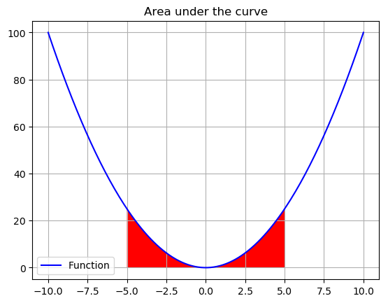

```python
import numpy as np
from scipy.integrate.quadpack import quad
import matplotlib.pyplot as plt
import matplotlib as mpl

mpl.style.use('default')

b = 5.0

# Function which is to be integrated
def func(x):
    return np.array(x**2)

x = np.linspace(-10, 10, 201)
integral, err = quad(func, 1, 5)
# Numerical quadrature that calculates the integral and error using fortran's quadpack library.

print("The integral is :", integral)
print("The error is :", err)

section = np.linspace(-5, 5, 20)

plt.plot(x, func(x), label='Function', color='b')
plt.fill_between(section, func(section), facecolor='red')
plt.grid()
plt.legend()
plt.title('Area under the curve')
plt.show()
```

## Another Example!

$E_{\lambda}(\lambda, T) = \frac{2\pi\ hc^2}{\lambda^5}\frac{1.0}{\exp{\left[\frac{hc}{\lambda k_BT}\right]}-1} Wm^{-2}K^{-1}\mu m^{-1}$

- Plot the black body energy curves for the Sun ($T_{surf} = 5770.0\ K$)
- Calculate the energy flux for the entire visible region and show this as a fraction of the total energy flux
- Compare this black body radiation curve with curves for temperature 4000.0, 5000.0, 6000.0 K.

```
The total Energy flux is : 62851322.5873358
The Energy flux in the band is : 29217830.60463064
The Energy flux Fraction is: 0.46487216818756133
The error is : 3.24383082668585e-07
```

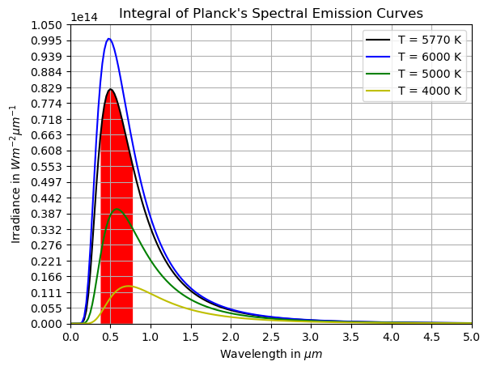

```python
from scipy.constants import codata
import numpy as np
from scipy.integrate.quadpack import quad
import matplotlib.pyplot as plt
import matplotlib as mpl

mpl.style.use('default')

# get physical from module:
D = codata.physical_constants

s = D['Stefan-Boltzmann constant'][0]

# Put the variable that you want to integrate first!
def spectra(l,T):
    h = D['Planck constant'][0]
    k = D['Boltzmann constant'][0]
    c = D['speed of light in vacuum'][0]
    func = ((2.0*h*np.pi*c**2)/(l**5))/(np.exp(h*c/(l*k*T)) - 1.0)
    return func

T1 = 5770.0
T2 = 6000.0
T3 = 5000.0
T4 = 4000.0

int1,err1 = quad(spectra, 0.38e-6, 0.78e-6, args=(T1))

E1 = s*T1**4

l = np.linspace(0, 5e-6, 201)

s1 = spectra(l, T1)
s2 = spectra(l, T2)
s3 = spectra(l, T3)
s4 = spectra(l, T4)

print("The total Energy flux is :", E1)
print("The Energy flux in the band is :", int1)
print("The Energy flux Fraction is:", int1/E1)
print("The error is :", err1)

section = np.linspace(0.38e-6, 0.78e-6, 20)

plt.plot(l*1e6, s1, 'k', label='T = 5770 K')
plt.plot(l*1e6, s2, 'b', label='T = 6000 K')
plt.plot(l*1e6, s3, 'g', label='T = 5000 K')
plt.plot(l*1e6, s4, 'y', label='T = 4000 K')
plt.fill_between(section*1e6, spectra(section, T1), facecolor='red')
plt.legend()
plt.grid('on')
plt.axis([0.0, 5.0, 0.0e13, 10.5e13])
plt.xticks(np.linspace(0.0, 5.0, 11))
plt.yticks(np.linspace(0.0e13, 10.5e13, 20))
plt.xlabel('Wavelength in $\mu m$')
plt.ylabel('Irradiance in $Wm^{-2}\mu m^{-1}$')
plt.title("Integral of Planck's Spectral Emission Curves")
plt.savefig('images/Spectra.png', format='png', dpi=600)
plt.show()
```

### Other functions in `scipy.integrate`

[Refer here](https://docs.scipy.org/doc/scipy/reference/generated/scipy.integrate.quad.html#scipy.integrate.quad)

# Differentiation in Python

This is rather straight forward

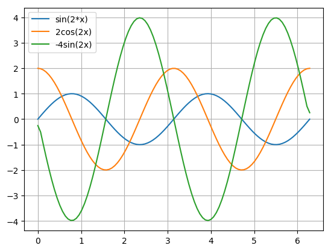

```python
x = np.linspace(0, 2.0*np.pi, 100)
y = np.sin(2*x)
y1 = np.gradient(y, x[1]-x[0]) # Calculates the Differential
y2 = np.gradient(y1, x[1]-x[0])

plt.plot(x, y, label='sin(2*x)')
plt.plot(x, y1, label='2cos(2x)')
plt.plot(x, y2, label='-4sin(2x)')
plt.legend()
plt.grid()
plt.savefig('images/Differentiation.png', format='png', dpi=400)
```

# Symbolic Operations in Python

This is done using sympy module. (Symbolic Python Module)

You can do:

- Symbolic Integration
- Symbolic Differentiation
- Symbolic Transformations
- Solve functions and equations

```python
import sympy as sym

x = sym.Symbol('x')
sym.integrate(x**2 + 2*x + 1)
```

$\displaystyle \frac{x^{3}}{3} + x^{2} + x$

```python
x = sym.Symbol('x')
sym.integrate(x**2 + sym.sin(x))
```

$\displaystyle \frac{x^{3}}{3} - \cos{\left(x \right)}$

```python
l = sym.Symbol('l')
T = sym.Symbol('T')
sym.integrate(sym.sin(2*sym.pi*l/T), l)
```

$\displaystyle \begin{cases} - \frac{T \cos{\left(\frac{2 \pi l}{T} \right)}}{2 \pi} & \text{for}\: \frac{2 \pi}{T} \neq 0 \\0 & \text{otherwise} \end{cases}$

```python
x = sym.Symbol('x')
sym.diff(x**2 + sym.sin(x))
```

$\displaystyle 2 x + \cos{\left(x \right)}$

```python
l = sym.Symbol('l')
T = sym.Symbol('T')
sym.diff(sym.sin(2*sym.pi*l/T), l)
```

$\displaystyle \frac{2 \pi \cos{\left(\frac{2 \pi l}{T} \right)}}{T}$

## Let's transition from symbolic computation to numerical computation

```python
x = sym.Symbol('x')
f = 2*x**2+3
f_prime = f.diff(x)

f_prime
```

$\displaystyle 4 x$

```python
### Let's make it numerical

fx = sym.lambdify(x, f)
fx_dash = sym.lambdify(x, f_prime)

print(f"f(3) = {fx(3)}, f'(3) = {fx_dash(3)}")
```

```
f(3) = 21, f'(3) = 12
```

```python
from sympy.integrals import laplace_transform as lt
from sympy.abc import t, s # Standard symbols
lt(t**2 + 2*t + 1, t, s)
```

```
((s**2 + 2*s + 2)/s**3, 0, True)
```

```python
y = sym.Symbol('y')
sym.expand((x+y)**3)
```

$\displaystyle x^{3} + 3 x^{2} y + 3 x y^{2} + y^{3}$

```python
sym.solve(x**4 - 1, x)
```

```
[-1, 1, -I, I]
```

```python
f = x**4 - 3*x**2 + 1
sym.factor(f)
```

$\displaystyle \left(x^{2} - x - 1\right) \left(x^{2} + x - 1\right)$

## Solving an ODE:

### Mass Spring Damper

Scipy library has quite a lot of functions to do it.

For Example, Let's see how a mass-spring-damper system is solved!

$ m\ddot{x} + c\dot{x} + kx = F_0\sin{\omega t}$

$x(t = 0) = 0$ and $\dot{x}(t = 0) = 0$

$ \ddot{x} = \left[\frac{F_0\sin{\omega t}}{m} - \frac{c\dot{x}}{m} - \frac{kx}{m} \right]$

Let

$\dot{x} = x_1$

$\dot{x_1} = \ddot{x} = \left[\frac{F_0\sin{\omega t}}{m} - \frac{c\dot{x_1}}{m} - \frac{kx}{m} \right]$

We need:

```
* A function that represents the equation and derivatives
* odeint function from scipy
* Initial conditions
```

```
'''
Numerical Integration Library

Contains functions for numerical integration
'''

import numpy as np

def rk4(inp_func, init_conditions, t, args):

    nt = len(t)
    n_outs = len(init_conditions)

    # print("init_conditions = ", init_conditions)

    states = np.zeros((nt, n_outs))
    k1 = np.zeros((nt, n_outs))
    k2 = np.zeros((nt, n_outs))
    k3 = np.zeros((nt, n_outs))
    k4 = np.zeros((nt, n_outs))

    dt = t[1] - t[0]

    states[0,:] = init_conditions

    for i in range(1, nt):
        var_ins = states[i-1,:]
        k1[i-1,:] = inp_func(var_ins, t[i], *args)
        k2[i-1,:] = inp_func(var_ins+k1[i-1,:]*dt*0.5, t[i], *args)
        k3[i-1,:] = inp_func(var_ins+k2[i-1,:]*dt*0.5, t[i], *args)
        k4[i-1,:] = inp_func(var_ins+k3[i-1,:]*dt, t[i], *args)

        states[i,:] = var_ins + (k1[i-1,:] + 2.0*k2[i-1,:] + 2.0*k3[i-1,:] + k4[i-1,:])*dt/6.0
        # print(i, states[i,:])

    return states
```

```
import numpy as np
from scipy.integrate import odeint
import matplotlib.pyplot as plt
from NumIntLib import rk4

def dampfunc(x, t, F0, omg, m, c, k):
    x0 = x[0] # Displacement
    x1 = x[1] # Velocity
    x2 = F0*np.sin(omg*t)/m - c*x1/m - k*x0/m # Acceleration
    return x1, x2

F0 = 50.0
omg = 1.0
m = 2.0
c = 1.0
k = 20

params = (F0, omg, m, c, k)

init = [0.0, 0.0] # Initial conditions
t = np.linspace(0.0, 10.0, 101)

x = odeint(dampfunc, init, t, args=params) # This is the vital part!
# x = rk.rk4(dampfunc, init, t, args=params) # This is the vital part!

acc = F0*np.sin(omg*t)/m - c*x[:,1]/m - k*x[:,0]/m

plt.plot(t, x[:,0], 'b', label='$x (m)$')
plt.plot(t, x[:,1], 'r', label='$\dot{x} (m/s)$')
plt.plot(t, acc, 'g', label='$\ddot{x} (m/s^2)$')
plt.axis([0, 10, -10, 10])
plt.xticks(np.linspace(0,10,11))
plt.yticks(np.linspace(-10,10,11))
plt.grid()
plt.legend()
plt.title('Solution to a Mass Spring Damper System')
plt.suptitle('Session 3, Demos')
plt.xlabel('Time in s')
plt.ylabel('Magnitudes')
plt.savefig('images/Mass_Spring_Damper.jpg', format='jpg', dpi=200)
```

### Solution to Lorenz Attractor

$ \dot{x} = \sigma(y-x)$

$ \dot{y} = (\rho - z)x - y$

$ \dot{z} = xy - \beta z$

where: $\sigma = 10$, $\rho = 28$, $\beta = \frac{8}{3}$

Initial Conditions: $x(t = 0) = y(t = 0) = z(t = 0) = 1.0$

```
import numpy as np
from scipy.integrate import odeint
import matplotlib.pyplot as plt
from NumIntLib import rk4

def lorenz(st, t, s, p, b):

    x0 = st[0] # x displacement
    y0 = st[1] # y displacement
    z0 = st[2] # z displacement

    xd = s*(y0-x0)
    yd = (p-z0)*x0 - y0
    zd = x0*y0 - b*z0

    return xd, yd, zd

s = 10.0
p = 28.0
b = 8.0/3.0

init = [1.0, 1.0, 1.0]
params = (s, p, b)
t = np.arange(0.0, 60.0, 0.01)

# st = odeint(lorentz, init, t, args=params)
st = rk.rk4(lorenz, init, t, args=params)

x = st[:,0]
y = st[:,1]
z = st[:,2]

from mpl_toolkits.mplot3d import Axes3D
fig = plt.figure()
ax = fig.gca(projection='3d')
ax.plot(x, y, z, 'r', label='Lorenz Butterfly')
ax.set_xlabel('x')
ax.set_ylabel('y')
ax.set_zlabel('z')
ax.legend()
plt.savefig('Lorenz_Butterfly.png', format='png', dpi=400)
```

# FFT and IFFT

This is possible using numpy and scipy modules

- Use fourier filtering to remove certain frequencies
- Show the power spectra of the original signal
- Also, perform differentiation of the original signal in frequency domain

```
# Program to try and work out the power spectrum

import numpy as np
import matplotlib.pyplot as plt
from scipy.fft import fft, fftfreq, ifft

n = 1024
Lx = 100
omg = 2.0*np.pi/Lx

x = np.linspace(0, Lx, n)
y1 = 1.0*np.cos( 5.0*omg*x)
y2 = 1.0*np.sin(10.0*omg*x)
y3 = 0.5*np.sin(20.0*omg*x)
y = y1 + y2 + y3
act = y1 + y2
yd_true = (omg)*( -5.0*1.0*np.sin(5.0*omg*x) + 10.0*1.0*np.cos(10.0*omg*x) + 20.0*0.5*np.cos(20.0*omg*x))

mean_y = np.mean(y)
std_y = np.std(y)
var_y = std_y**2.0

print(mean_y, std_y, var_y)

# Creates all the necessary frequencies
freqs = fftfreq(n)

# Arranges the frequencies in ascending order
idx = np.argsort(freqs)

# wave numbers
nwaves = freqs*n
nwaves_2pi = omg*nwaves

# mask array to be used for power spectra.
# ignoring half the values, as they are complex conjucates of the other
mask = freqs > 0

# fft values
fft_vals = fft(y)

# Fourier filtering
fft_new = np.copy(fft_vals)
fft_new[np.abs(nwaves)==20] = 0.0

# inverse fourier transform to reconstruct the filtered data
filt_data = np.real(ifft(fft_new))

# derivative of y in frequency spectrum
yd_fft = 1.0j*nwaves_2pi*fft_vals
yd_recon = np.real(ifft(yd_fft))

# this is the power spectra
ps = 2.0*np.abs(fft_vals/n)**2.0

# power by variance
pow_var = ps/var_y*100.0

# freq.power spectra - for variance preserving form
fps = ps*freqs

#print(fft_vals)
#print(np.abs(fft_vals*2.0/n))
print(np.sum(ps[mask]))

plt.figure(1)
plt.title('Original Signal')
plt.plot(x, y, color='xkcd:salmon', label='original')
plt.legend()

plt.figure(2)
plt.plot(nwaves[mask], ps[mask], label='wavenumber vs spectra')
plt.title('Power Spectrum Example - wavenumber vs spectra')
plt.legend()

plt.figure(3)
plt.title('Data Filtering example')
plt.plot(x, act, color='black', label='theoretical')
plt.plot(x, filt_data, color='cyan', label='via fourier filtering')
plt.legend()

plt.figure(4)
plt.title('Derivative of the signal')
plt.plot(x, yd_true, color='black', label='theoretical')
plt.plot(x, yd_recon, color='cyan', label='via spectral method')
plt.legend()
plt.show()
```

# Session 2

Matplotlib is one fundamental plotting package in python - quick to use, no nonsense, and to the point.

But, this the disadvantage of Matplotlib as well!

There are other plotting packages available for a bigger more massive variety of applications!

- Plotly
- Bokeh
- Seaborn

## Plotly

- Has features to make interactive HTML plots.
- Using Dash, you can make interactive web-applications
- Has an online and an offline version.

Let's get started

```
# Plotly example tutorial

import numpy as np
import plotly.graph_objs as go
import plotly.offline as ply

# Create sample data
n = 201
x = np.linspace(0, 2.0*np.pi, n)
y1 = np.sin(x)
y2 = np.cos(x)
y3 = y1 + y2

## Plotly steps begin

# Create traces - data collections
trace1 = go.Scatter(
    x = x,
    y = y1,
    name = "sine curve",
    line = dict(
        color = ("red"),
        width = 4,
        dash = 'dash'
    )
)

trace2 = go.Scatter(
    x = x,
    y = y2,
    name = "cosine curve",
    line = dict(
        color = ("green"),
        width = 4,
        dash = 'dot' # dot, dashdot
    )
)

trace3 = go.Scatter(
    x = x,
    y = y3,
    name = "sine + cosine curve",
    line = dict(
        color = ("blue"),
        width = 4,
        dash = "dashdot"
    )
)

# Create information / layout dictionary
layout = dict(
    title = "Some sample sinusoidal curves",
    xaxis = dict(title = "Angle in Radian"),
    yaxis = dict(title = "Magnitude")
)

# Pack the data
data = [trace1, trace2, trace3]

# Create a figure
fig = dict(data = data, layout = layout)

# Plot
ply.plot(fig, filename='simple_plot.html')
```